# Unsupervised Learning: Trade & Ahead

## EDA

- It is a good idea to explore the data once again after manipulating it.

```python
df.describe()
```

|  | Current Price | Price Change | Volatility | ROE | Cash Ratio | Net Cash Flow | Net Income | Earnings Per Share | Estimated Shares Outstanding | P/E Ratio | P/B Ratio | Market Cap | GICS Sector_Consumer Discretionary | GICS Sector_Consumer Staples | GICS Sector_Energy | GICS Sector_Financials | GICS Sector_Health Care | GICS Sector_Industrials | GICS Sector_Information Technology | GICS Sector_Materials | GICS Sector_Real Estate | GICS Sector_Telecommunications Services | GICS Sector_Utilities | GICS Sub Industry_Advertising | GICS Sub Industry_Aerospace & Defense | GICS Sub Industry_Agricultural Products | GICS Sub Industry_Air Freight & Logistics | GICS Sub Industry_Airlines | GICS Sub Industry_Alternative Carriers | … |
| --- | --- | --- | --- | --- | --- | --- | --- | --- | --- | --- | --- | --- | --- | --- | --- | --- | --- | --- | --- | --- | --- | --- | --- | --- | --- | --- | --- | --- | --- | --- |
| count | 285.000000 | 285.000000 | 285.000000 | 285.000000 | 285.000000 | 285.000000 | 285.000000 | 285.000000 | 285.000000 | 285.000000 | 285.000000 | 2.850000e+02 | 285.000000 | 285.000000 | 285.000000 | 285.000000 | 285.000000 | 285.000000 | 285.000000 | 285.000000 | 285.000000 | 285.000000 | 285.000000 | 285.000000 | 285.000000 | 285.000000 | 285.000000 | 285.000000 | 285.000000 | … |
| mean | -0.084979 | 0.055726 | -0.157304 | -0.151559 | -0.128000 | -0.024276 | -0.032463 | 0.086180 | -0.161928 | -0.145646 | 0.008464 | 2.769733e+10 | 0.105263 | 0.052632 | 0.052632 | 0.150877 | 0.115789 | 0.182456 | 0.087719 | 0.066667 | 0.094737 | 0.007018 | 0.084211 | 0.007018 | 0.014035 | 0.003509 | 0.010526 | 0.017544 | 0.003509 | … |
| std | 0.508605 | 0.823698 | 0.707814 | 0.360809 | 0.602946 | 0.487060 | 0.505767 | 0.521125 | 0.500117 | 0.451828 | 0.564262 | 3.046522e+10 | 0.307432 | 0.223690 | 0.223690 | 0.358559 | 0.320535 | 0.386899 | 0.283384 | 0.249883 | 0.293366 | 0.083623 | 0.278192 | 0.083623 | 0.117842 | 0.059235 | 0.102236 | 0.131517 | 0.059235 | … |
| min | -0.750311 | -2.324620 | -1.341642 | -0.400362 | -0.775555 | -2.341927 | -2.369738 | -2.402928 | -0.650430 | -0.670162 | -2.100701 | 3.012168e+09 | 0.000000 | 0.000000 | 0.000000 | 0.000000 | 0.000000 | 0.000000 | 0.000000 | 0.000000 | 0.000000 | 0.000000 | 0.000000 | 0.000000 | 0.000000 | 0.000000 | 0.000000 | 0.000000 | 0.000000 | … |
| 25% | -0.409070 | -0.378855 | -0.667995 | -0.307006 | -0.576194 | -0.125823 | -0.285935 | -0.159113 | -0.489228 | -0.401286 | -0.187066 | 9.534314e+09 | 0.000000 | 0.000000 | 0.000000 | 0.000000 | 0.000000 | 0.000000 | 0.000000 | 0.000000 | 0.000000 | 0.000000 | 0.000000 | 0.000000 | 0.000000 | 0.000000 | 0.000000 | 0.000000 | 0.000000 | … |
| 50% | -0.214096 | 0.070049 | -0.295098 | -0.255142 | -0.288227 | -0.027446 | -0.190218 | 0.035472 | -0.336104 | -0.296766 | 0.032189 | 1.713677e+10 | 0.000000 | 0.000000 | 0.000000 | 0.000000 | 0.000000 | 0.000000 | 0.000000 | 0.000000 | 0.000000 | 0.000000 | 0.000000 | 0.000000 | 0.000000 | 0.000000 | 0.000000 | 0.000000 | 0.000000 | … |
| 75% | 0.101599 | 0.521378 | 0.105634 | -0.151413 | 0.320933 | 0.053235 | 0.066749 | 0.284785 | -0.054225 | -0.082116 | 0.363059 | 3.042318e+10 | 0.000000 | 0.000000 | 0.000000 | 0.000000 | 0.000000 | 0.000000 | 0.000000 | 0.000000 | 0.000000 | 0.000000 | 0.000000 | 0.000000 | 0.000000 | 0.000000 | 0.000000 | 0.000000 | 0.000000 | … |
| max | 2.637786 | 2.786922 | 2.588882 | 2.317327 | 2.912632 | 2.856733 | 2.972692 | 2.545322 | 2.645455 | 2.233634 | 1.833811 | 1.779355e+11 | 1.000000 | 1.000000 | 1.000000 | 1.000000 | 1.000000 | 1.000000 | 1.000000 | 1.000000 | 1.000000 | 1.000000 | 1.000000 | 1.000000 | 1.000000 | 1.000000 | 1.000000 | 1.000000 | 1.000000 | … |

```python
df.columns
```

```
Index(['Ticker Symbol', 'Security', 'Current Price', 'Price Change',
       'Volatility', 'ROE', 'Cash Ratio', 'Net Cash Flow', 'Net Income',
       'Earnings Per Share',
       ...
       'GICS Sub Industry_Specialty Retail',
       'GICS Sub Industry_Specialty Stores', 'GICS Sub Industry_Steel',
       'GICS Sub Industry_Technology Hardware, Storage & Peripherals',
       'GICS Sub Industry_Technology, Hardware, Software and Supplies',
       'GICS Sub Industry_Thrifts & Mortgage Finance',
       'GICS Sub Industry_Tires & Rubber', 'GICS Sub Industry_Tobacco',
       'GICS Sub Industry_Trucking', 'GICS Sub Industry_Water Utilities'],
      dtype='object', length=129)
```

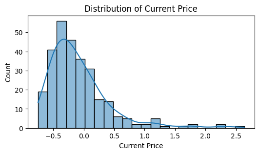

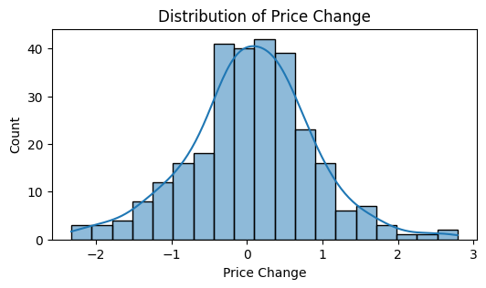

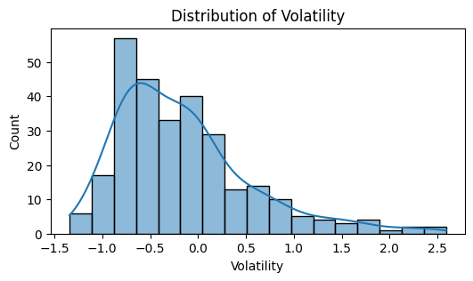

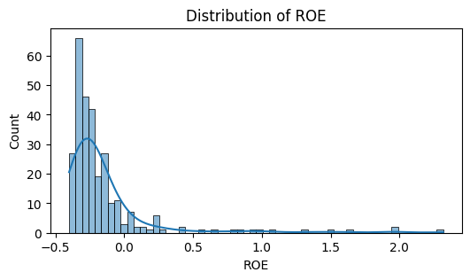

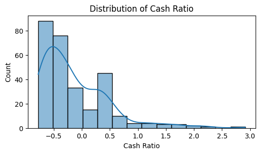

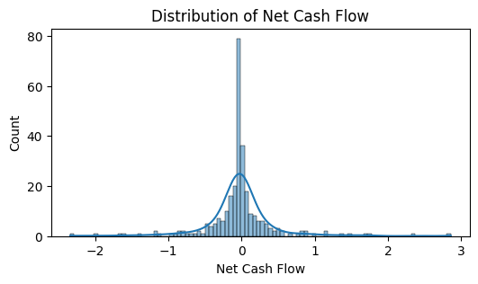

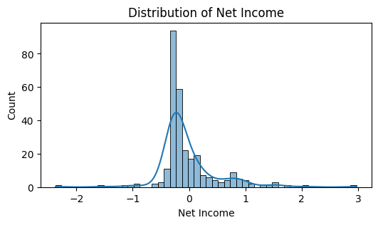

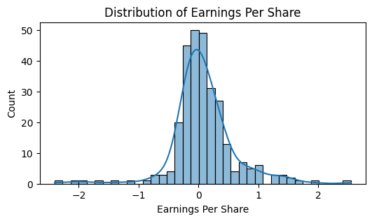

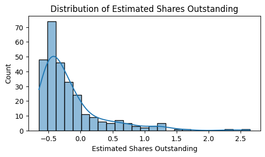

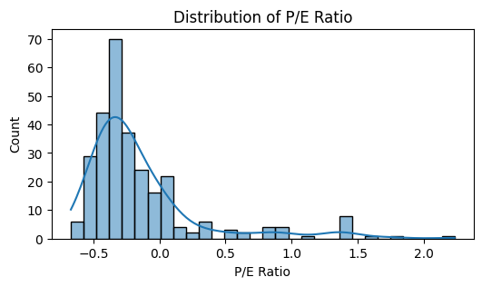

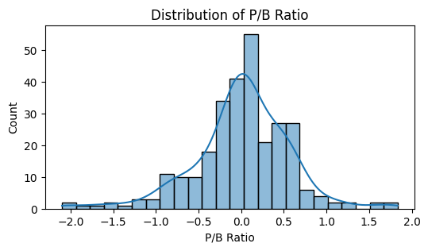

```python
#checking updated distributions

for col in numeric_cols:
    plt.figure(figsize=(6, 3))
    sns.histplot(df[col].dropna(), kde=True)
    plt.title(f'Distribution of {col}')
    plt.show()
```

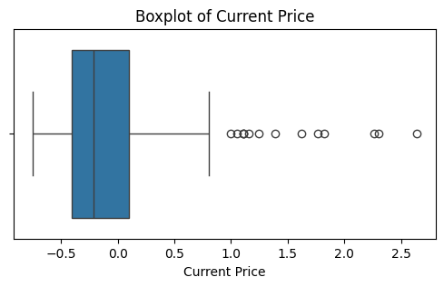

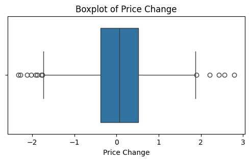

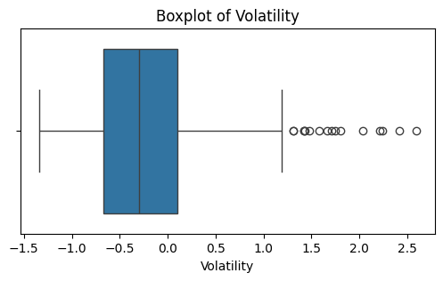

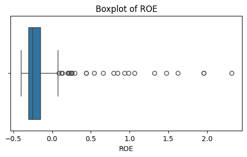

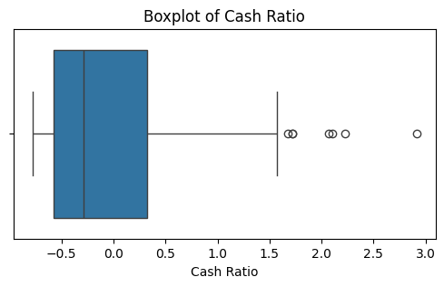

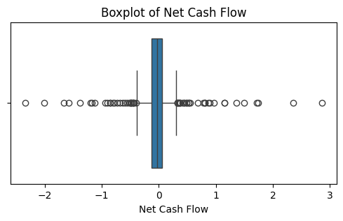

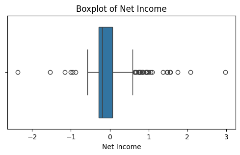

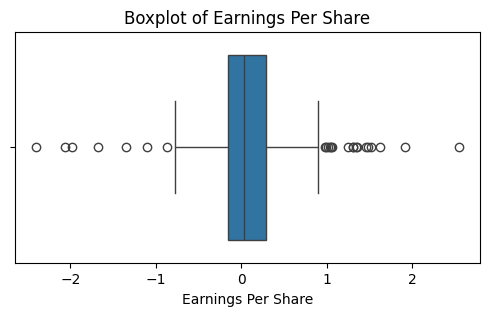

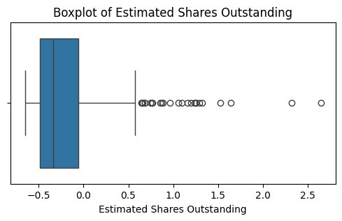

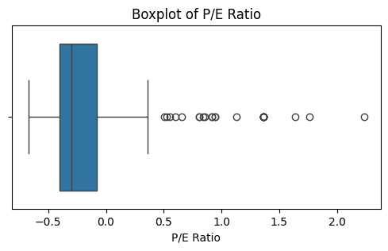

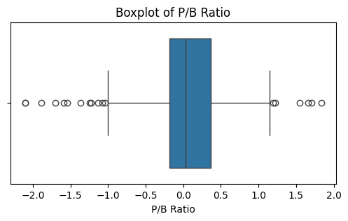

```python
#visualizing any remaining outliers
for col in numeric_cols:
    plt.figure(figsize=(6, 3))
    sns.boxplot(x=df[col])
    plt.title(f'Boxplot of {col}')
    plt.show()
```

## K-means Clustering

```python
from sklearn.preprocessing import StandardScaler

scaler = StandardScaler()
X_scaled = scaler.fit_transform(df[numeric_cols])  # Using selected numeric columns
```

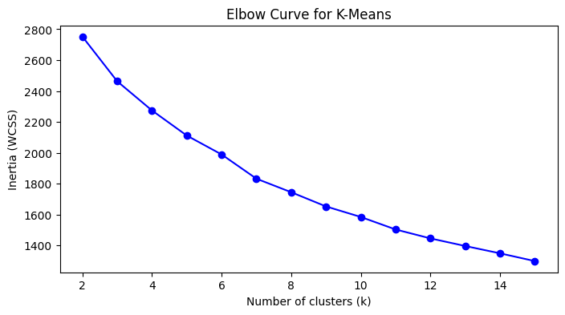

```python
#Plotting Elbow Curve
from sklearn.cluster import KMeans

inertia = []
K = range(2, 16)  # Trying k from 2 to 15

for k in K:
    kmeans = KMeans(n_clusters=k, random_state=42, n_init=10)
    kmeans.fit(X_scaled)
    inertia.append(kmeans.inertia_)

plt.figure(figsize=(8, 4))
plt.plot(K, inertia, 'bo-')
plt.xlabel('Number of clusters (k)')
plt.ylabel('Inertia (WCSS)')
plt.title('Elbow Curve for K-Means')
plt.show()
```

```python
#choosing K=2 as the final K
kmeans = KMeans(n_clusters=2, random_state=42, n_init=10)
df['Cluster'] = kmeans.fit_predict(X_scaled)
```

```python
#cluster centroids
centroids = kmeans.cluster_centers_
print(centroids)
```

```
[[ 0.76187735  0.1607069  -0.31919904  0.88752234  0.04329884  0.23714068
   1.25762261  1.07119634  0.63241487 -0.44464032 -0.2353888 ]
 [-0.20747553 -0.04376393  0.08692474 -0.24169135 -0.0117912  -0.06457849
  -0.34247759 -0.29170972 -0.17222012  0.12108509  0.06410141]]
```

```python
#summary stats per cluster
print(df.groupby('Cluster')[numeric_cols].mean())
```

```
         Current Price  Price Change  Volatility       ROE  Cash Ratio  \
Cluster
0             0.301836      0.187867   -0.382841  0.168105   -0.101939
1            -0.190317      0.019741   -0.095885 -0.238610   -0.135097

         Net Cash Flow  Net Income  Earnings Per Share  \
Cluster
0             0.091023    0.602483            0.643427
1            -0.055674   -0.205373           -0.065570

         Estimated Shares Outstanding  P/E Ratio  P/B Ratio
Cluster
0                            0.153798  -0.346194  -0.124124
1                           -0.247907  -0.091032   0.044571
```

```python
#identifying important features
overall_mean = df[numeric_cols].mean()
centroid_diff = centroids[1] - centroids[0]

#show top 3 features that most distinguish each cluster
for i in range(len(centroid_diff)):
  print(f"Cluster {i} distinguishing features:")
  feature_diffs = pd.Series(centroid_diff, index=numeric_cols)
  print(feature_diffs.abs().sort_values(ascending=False).head(3))
  print()
```

```
Cluster 0 distinguishing features:
Net Income            1.600100
Earnings Per Share    1.362906
ROE                   1.129214
dtype: float64

Cluster 1 distinguishing features:
Net Income            1.600100
Earnings Per Share    1.362906
ROE                   1.129214
dtype: float64

Cluster 2 distinguishing features:
Net Income            1.600100
Earnings Per Share    1.362906
ROE                   1.129214
dtype: float64

Cluster 3 distinguishing features:
Net Income            1.600100
Earnings Per Share    1.362906
ROE                   1.129214
dtype: float64

Cluster 4 distinguishing features:
Net Income            1.600100
Earnings Per Share    1.362906
ROE                   1.129214
dtype: float64

Cluster 5 distinguishing features:
Net Income            1.600100
Earnings Per Share    1.362906
ROE                   1.129214
dtype: float64

Cluster 6 distinguishing features:
Net Income            1.600100
Earnings Per Share    1.362906
ROE                   1.129214
```

[output cut: 10 more lines]

```
Earnings Per Share    1.362906
ROE                   1.129214
dtype: float64

Cluster 9 distinguishing features:
Net Income            1.600100
Earnings Per Share    1.362906
ROE                   1.129214
dtype: float64

Cluster 10 distinguishing features:
Net Income            1.600100
Earnings Per Share    1.362906
ROE                   1.129214
dtype: float64
```

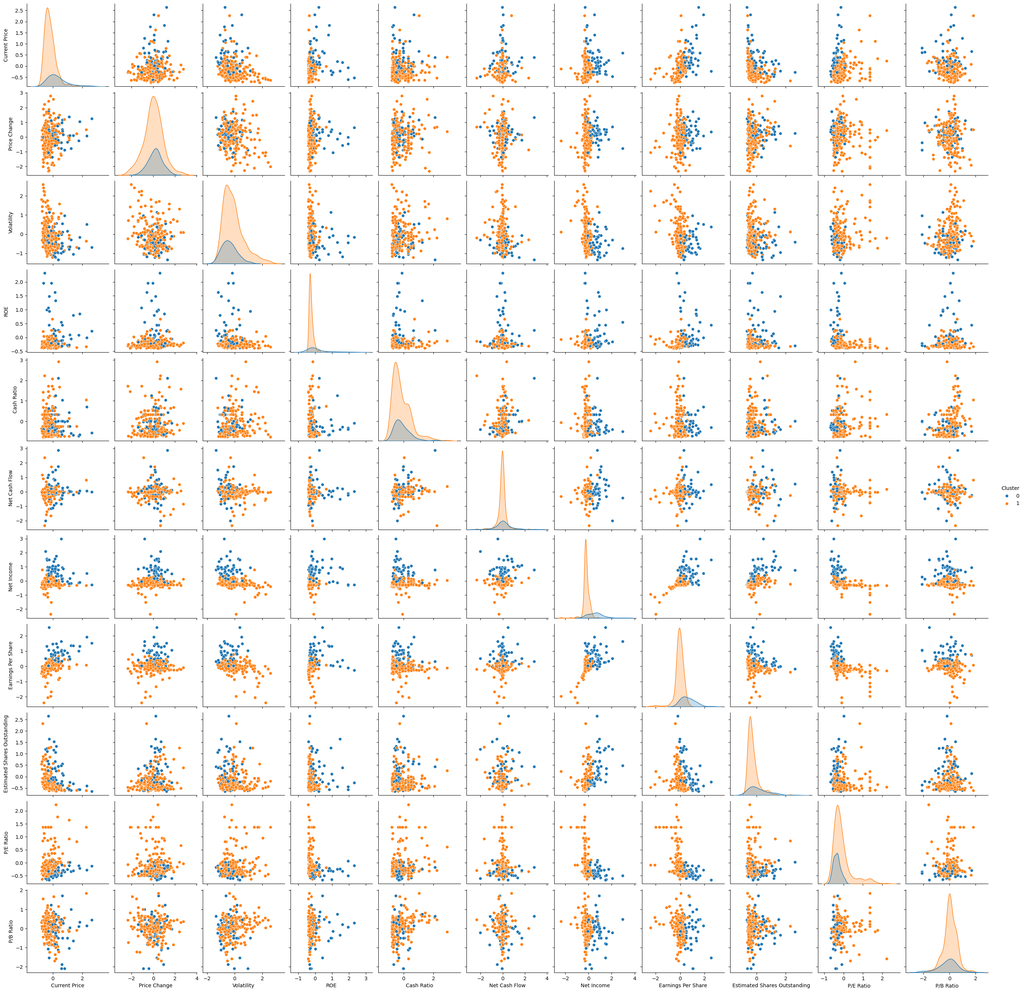

```python
#visualizing clusters
sns.pairplot(df, hue='Cluster',vars=numeric_cols)
plt.show()
```

## Hierarchical Clustering

```python
from scipy.cluster.hierarchy import dendrogram, linkage, cophenet, fcluster
from scipy.spatial.distance import pdist
from sklearn.metrics import silhouette_score
from sklearn.cluster import AgglomerativeClustering
```

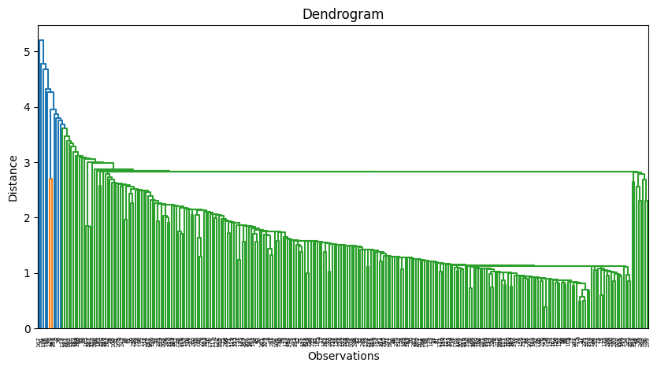

```python
#computing linkage matrix for dendogram
linkage_matrix = linkage(X_scaled, method='single', metric='euclidean')

#plotting the dendogram
plt.figure(figsize=(10, 5))
dendrogram(linkage_matrix)
plt.title('Dendrogram')
plt.xlabel('Observations')
plt.ylabel('Distance')
plt.show()
```

```python
#cophenetic corr
c, coph_dists = cophenet(linkage_matrix, pdist(X_scaled))
print("Cophenetic correlation coefficient:", c)
```

```
Cophenetic correlation coefficient: 0.8482702016808482
```

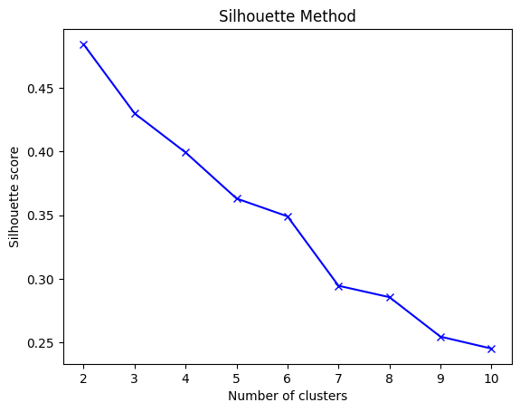

```
Optimal number of clusters: 2
```

```python
#determing best number of clusters using silhoette
range_n_clusters = range(2, 11)
silhouette_avgs = []

for n_clusters in range_n_clusters:
    cluster_lables = fcluster(linkage_matrix, n_clusters, criterion='maxclust')
    silhouette_avg = silhouette_score(X_scaled, cluster_lables)
    silhouette_avgs.append(silhouette_avg)


plt.plot(range_n_clusters, silhouette_avgs, 'bx-')
plt.xlabel('Number of clusters')
plt.ylabel('Silhouette score')
plt.title('Silhouette Method')
plt.show()



optimal_n_clusters = range_n_clusters[silhouette_avgs.index(max(silhouette_avgs))]
print("Optimal number of clusters:", optimal_n_clusters)
```

```python
#assigning cluster labels
fcluster_labels = fcluster(linkage_matrix, optimal_n_clusters, criterion='maxclust')
df['Cluster'] = fcluster_labels
```

```python
#cluster profile
cluster_profile = df.groupby('Cluster')[numeric_cols].mean()
print(cluster_profile)
```

```
         Current Price  Price Change  Volatility       ROE  Cash Ratio  \
Cluster
1            -0.086619      0.051263   -0.153133 -0.152984   -0.135859
2             0.380731      1.322990   -1.341642  0.253128    2.104110

         Net Cash Flow  Net Income  Earnings Per Share  \
Cluster
1            -0.034420   -0.035294            0.085390
2             2.856733    0.771389            0.310628

         Estimated Shares Outstanding  P/E Ratio  P/B Ratio
Cluster
1                           -0.164010  -0.145515   0.006262
2                            0.429385  -0.182962   0.633886
```

```python
#identify top 3 features
overall_mean = df[numeric_cols].mean()
diff = cluster_profile - overall_mean

#show top 3 features that most distinguish each cluster
for i in range(len(diff)):
  print(f"Cluster {i+1} distinguishing features:")
  feature_diffs = diff.iloc[i].abs().sort_values(ascending=False)
  print(feature_diffs.head(3))
  print()
```

```
Cluster 1 distinguishing features:
Net Cash Flow    0.010144
Cash Ratio       0.007860
Price Change     0.004462
Name: 1, dtype: float64

Cluster 2 distinguishing features:
Net Cash Flow    2.881008
Cash Ratio       2.232110
Price Change     1.267265
Name: 2, dtype: float64
```

## Actionable Insights and Recommendations

- Based on the Kmeans model, the clusters are primarily seperated by profitability metrics. Stocks group together are similar in profit generation and shareholder returns.

Recommendation: Investors seeking stable returns should focus on clusters with High Net Income, EPS, and ROE.

Investors with higher risk tolerance may want to explore clusters with a lower values for those metrics.

Use these clusters to diversify across different profitability profiles.

- The Hierarchical model suggest the clusters are defined by liquidity and more recent price movement.

Recommendations:

Conservative investors may prefer clusters with high cash flow and cash ratios.

Momentum or growth investors might target clusters with a high recent price change

Use liquidity based clusters to identify stocks that can withstand market volatility.

```python
#Converting Notebook to Html
from google.colab import files
! jupyter nbconvert --to html ''
files.download('')
```